# Universidade

- Centro Universitário Fundação Santo André

# Integrantes do grupo:

- Danilo Zampieri Cangussú  
  RA: 741882
- Helder da Silva Galbier  
  RA: 741359

# Professor Orientador

- Diego Marques de Carvalho

# Introdução

Aqui elencamos algumas análises sobre o conjunto de dados de diamentes/pedras preciosas, a fim de traçar um panorama dos diferentes cortes, quilates, cores, dentre outros aspectos que classificam a pedra preciosa em estudo, numa abordagem para um público leigo ou detém pouco conhecimento sobre o assunto.

# Descrição dataset e colunas

Esse é um quadro de dados sobre diamentes com 53.940 linhas e 10 variáveis:

- (price) preço em dólares americanos (\$326--\$18.823)
- (carat) peso do diamante (0,2--5,01)
- (cut) qualidade do corte (Razoável, Bom, Muito Bom, Premium, Ideal)
- (color) cor do diamante, de J (pior) a D (melhor)
- (clarity) uma medida de quão claro é o diamante (I1 (pior), SI2, SI1, VS2, VS1, VVS2, VVS1, IF (melhor))
- x comprimento em mm (0--10,74)
- y largura em mm (0--58,9)
- z profundidade em mm (0--31,8)
- porcentagem de profundidade total = z / média (x, y) = 2 * z / (x + y) (43--79)
- largura do topo do diamante em relação ao ponto mais largo (43–95)

```python
# Preparando drive
from google.colab import drive
drive.mount('/content/drive')
```

```python
# Importando bibliotecas

import seaborn as sns
import matplotlib.pyplot as plt
import pandas as pd
import numpy as np

# Importando Arquivo csv

file_path = '/content/drive/MyDrive/Colab Notebooks/diamonds.csv'

df = pd.read_csv('/content/drive/MyDrive/Colab Notebooks/diamonds.csv')
data = pd.read_csv("/content/drive/MyDrive/Colab Notebooks/diamonds.csv")
df.head()
```

|  | Unnamed: 0 | carat | cut | color | clarity | depth | table | price | x | y | z |
| --- | --- | --- | --- | --- | --- | --- | --- | --- | --- | --- | --- |
| 0 | 1 | 0.23 | Ideal | E | SI2 | 61.5 | 55.0 | 326 | 3.95 | 3.98 | 2.43 |
| 1 | 2 | 0.21 | Premium | E | SI1 | 59.8 | 61.0 | 326 | 3.89 | 3.84 | 2.31 |
| 2 | 3 | 0.23 | Good | E | VS1 | 56.9 | 65.0 | 327 | 4.05 | 4.07 | 2.31 |
| 3 | 4 | 0.29 | Premium | I | VS2 | 62.4 | 58.0 | 334 | 4.20 | 4.23 | 2.63 |
| 4 | 5 | 0.31 | Good | J | SI2 | 63.3 | 58.0 | 335 | 4.34 | 4.35 | 2.75 |

```python
media_price = data['price'].mean()
mediana_price = data['price'].median()
moda_price = data['price'].mode()
desvio_price = data ['price'].std()
variancia_price = data['price'].var()
amplitudemax_price = data['price'].max()
amplitudemin_price = data['price'].min()
q1_price = np.percentile(data['price'], 25)
q3_price = np.percentile(data['price'], 75)
itq_recursos = q3_price - q1_price

print(media_price)
print(mediana_price)
print(moda_price)
print(desvio_price)
print(variancia_price)
print(amplitudemax_price)
print(amplitudemin_price)
print(q1_price)
print(q3_price)
print(itq_recursos)
```

```
3932.799721913237
2401.0
0    605
Name: price, dtype: int64
3989.439738146379
15915629.42430145
18823
326
950.0
5324.25
4374.25
```

(https://www.kaggle.com/datasets/shivam2503/diamonds)

```python
media_x = data['x'].mean()
mediana_x = data['x'].median()
moda_x = data['x'].mode()
desvio_x = data ['x'].std()
variancia_x = data['x'].var()
amplitudemax_x = data['x'].max()
amplitudemin_x = data['x'].min()
q1_x = np.percentile(data['x'], 25)
q3_x = np.percentile(data['x'], 75)
itq_recursos = q3_quantidade - q1_quantidade

print(media_x)
print(mediana_x)
print(moda_x)
print(desvio_x)
print(variancia_x)
print(amplitudemax_x)
print(amplitudemin_x)
print(q1_x)
print(q3_x)
print(itq_recursos)
```

[output not shown]

```python
media_y = data['y'].mean()
mediana_y = data['y'].median()
moda_y = data['y'].mode()
desvio_y = data ['y'].std()
variancia_y = data['y'].var()
amplitudemax_y = data['y'].max()
amplitudemin_y = data['y'].min()
q1_y = np.percentile(data['y'], 25)
q3_y = np.percentile(data['y'], 75)
itq_recursos = q3_quantidade - q1_quantidade

print(media_y)
print(mediana_y)
print(moda_y)
print(desvio_y)
print(variancia_y)
print(amplitudemax_y)
print(amplitudemin_y)
print(q1_y)
print(q3_y)
print(itq_recursos)
```

[output not shown]

```python
media_z = data['z'].mean()
mediana_z = data['z'].median()
moda_z = data['z'].mode()
desvio_z = data ['z'].std()
variancia_z = data['z'].var()
amplitudemax_z = data['z'].max()
amplitudemin_z = data['z'].min()
q1_z = np.percentile(data['z'], 25)
q3_z = np.percentile(data['z'], 75)
itq_recursos = q3_quantidade - q1_quantidade

print(media_z)
print(mediana_z)
print(moda_z)
print(desvio_z)
print(variancia_z)
print(amplitudemax_z)
print(amplitudemin_z)
print(q1_z)
print(q3_z)
print(itq_recursos)
```

[output not shown]

# Questões para análise

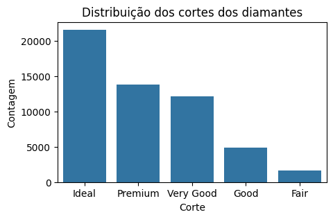

```python
# Primeira pergunta

# Qual é a distribuição das diferentes categorias de cortes (cut) dos diamantes no dataset?

plt.figure(figsize=(5, 3)) # Criando uma figura 5x3
sns.countplot(data=diamonds, x='cut')
plt.title('Distribuição dos cortes dos diamantes')
plt.xlabel('Corte')
plt.ylabel('Contagem')
plt.show()

# Observação: Muitas vezes confundido com a forma do diamante, o corte é, na verdade, a classificação que determina o brilho do diamante.
```

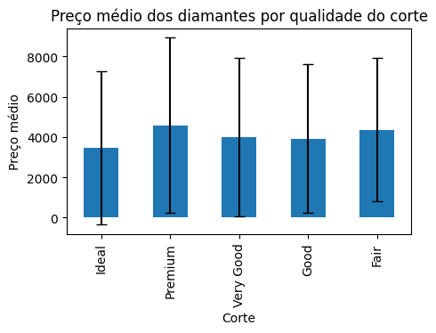

```python
# Segunda pergunta

# Como o preço dos diamantes varia com a qualidade do corte?

price_mean = diamonds.groupby('cut')['price'].mean()
price_std = diamonds.groupby('cut')['price'].std()

plt.figure(figsize=(5, 3))
price_mean.plot(kind='bar', yerr=price_std, capsize=4)
plt.title('Preço médio dos diamantes por qualidade do corte')
plt.xlabel('Corte')
plt.ylabel('Preço médio')
plt.show()
```

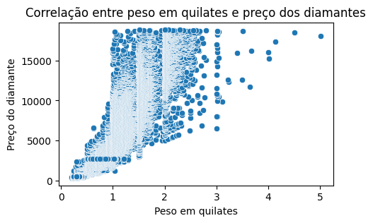

```
Correlação entre quilates e preço: 0.9215913011934771
```

```python
# Terceira pergunta

#  Existe uma correlação entre o peso em quilates e o preço dos diamantes?

plt.figure(figsize=(5, 3))
sns.scatterplot(data=diamonds, x='carat', y='price')
plt.title('Correlação entre peso em quilates e preço dos diamantes')
plt.xlabel('Peso em quilates')
plt.ylabel('Preço do diamante')
plt.show()

correlation = diamonds['carat'].corr(diamonds['price'])
print(f'Correlação entre quilates e preço: {correlation}')
```

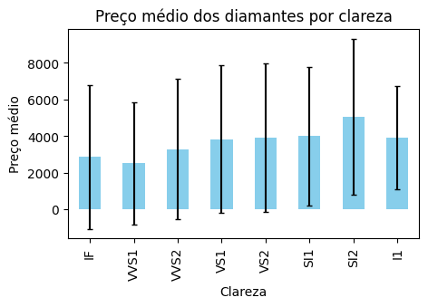

```python
# Quarta pergunta

# Como a clareza dos diamantes afeta o preço?

price_mean_clarity = diamonds.groupby('clarity')['price'].mean()
price_std_clarity = diamonds.groupby('clarity')['price'].std()

plt.figure(figsize=(5, 3))
price_mean_clarity.plot(kind='bar', yerr=price_std_clarity, capsize=2, color='skyblue')
plt.title('Preço médio dos diamantes por clareza')
plt.xlabel('Clareza')
plt.ylabel('Preço médio')
plt.show()
```

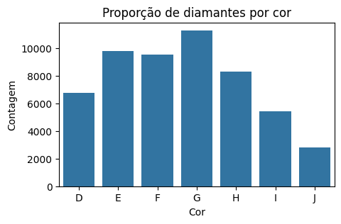

```python
# Quinta pergunta

#  Qual é a proporção de diamantes em cada categoria de cor?

plt.figure(figsize=(5, 3))
sns.countplot(data=diamonds, x='color') # Contagem de cada categoria de cor do ds diamonds
plt.title('Proporção de diamantes por cor')
plt.xlabel('Cor')
plt.ylabel('Contagem')
plt.show()
```

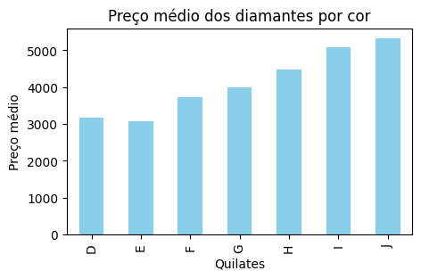

```python
# Sexta pergunta

# Existe uma diferença significativa no preço dos diamantes baseando-se na cor?

plt.figure(figsize=(5, 3))
price_mean_color = diamonds.groupby('color')['price'].mean()
price_mean_color.plot(kind='bar', color='skyblue')
plt.title('Preço médio dos diamantes por cor')
plt.xlabel('Quilates')
plt.ylabel('Preço médio')
plt.show()
```

```python
# Sétima pergunta

# Qual é a média do preço dos diamantes no conjunto de dados?

media_preco_diamantes = diamonds['price'].mean()

print("A média do preço dos diamantes é:", media_preco_diamantes)
```

```
A média do preço dos diamantes é: 3932.799721913237
```

```python
# Oitava pergunta

# Qual é a média do tamanho (em milímetros) dos diamantes no conjunto de dados?

# Observação: A Coluna X é referente ao comprimento do diamante em milímetros.

media_tamanho_diamantes_mm = diamonds['x'].mean()

print("A média do tamanho dos diamantes em milímetros é: {:.2f}".format(media_tamanho_diamantes_mm))
```

```
A média do tamanho dos diamantes em milímetros é: 5.73
```

```python
# Nona pergunta

# Qual é a média da profundidade (em milímetros) dos diamantes no conjunto de dados?

# Observação: A Coluna Z é referente ao comprimento da profundidade do diamante em milímetros.

media_profundidade_diamantes_mm = diamonds['z'].mean()

print("A média da profundidade do diamante em milímetros é: {:.2f}".format(media_profundidade_diamantes_mm))
```

```
A média da profundidade do diamante em milímetros é: 3.54
```

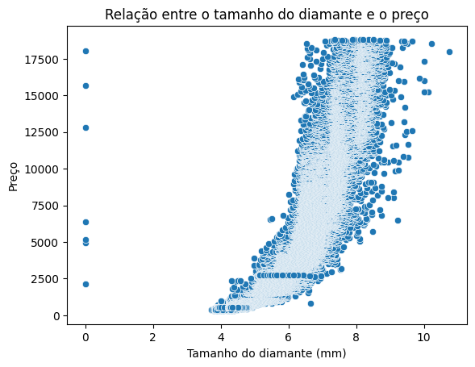

```python
# Décima pergunta

# Qual é a relação entre o tamanho do diamante e o preço?

sns.scatterplot(data=diamonds, x='x', y='price')
plt.xlabel('Tamanho do diamante (mm)')
plt.ylabel('Preço')
plt.title('Relação entre o tamanho do diamante e o preço')
plt.show()
```